# Full Capstone Code with Notes

Max Davis

10/20/2019

Load libraries that I will use for exploring the data, and for cleaning it.

```r
set.seed(2555)
library(readr)
library(dplyr)
library(tidyr)
library(ggplot2)
library(data.table)
```

Read data for full Haute Born Wind farm from 2017 to 2020, and the data description file or metadata using the fread() function with data.table = FALSE:

```r
haute_all_2017_2020 <- fread("la-haute-borne-data-2017-2020.csv", data.table = FALSE)
data_description <- fread("data_description.csv")
```

Make tibble of data:

```r
haute <- tbl_df(haute_all_2017_2020)
metadata <- tbl_df(data_description)
```

Make a list of old names and one of replacement names from metadata:

```r
old <- metadata[,"Variable_name"]
new <- metadata[, "Variable_long_name"]
```

Create a function to replace old names with a corresponding longer name on the new names list:

```r
fast_clean <- function(df, x) {colnames(df) <- gsub (old[[c(1, x)]], new[[c(1, x)]], colnames(df)) ; df}
```

Apply the fast_clean function first to two column names that would create distortions in a while loop:

```r
haute<- fast_clean(haute, 20)
haute<- fast_clean(haute, 27)
```

Use a while loop to take the old part of each column name and replace it by increments, skipping variable 20 and 27, which I have already done in the previous code chunk:

```r
n <- 1
while(n < 20) {haute <- fast_clean(df = haute, x = n)
  n <- (n + 1)
  }
n <- 21
while(n < 27) {haute <- fast_clean(df = haute, x = n)
  n <- (n + 1)
  }
n <- 28
while(n <= 34) {haute <- fast_clean(df = haute, x = n)
  n <- (n + 1)
  }
```

Separate date and time in the datetime column:

```r
haute <- separate(haute, "Date_time", c("date", "time"), sep = "T", remove = TRUE, convert = FALSE, extra = "warn", fill = "warn")
```

Make Date into date format:

```r
haute$date <- as.Date(haute$date, "%Y-%m-%d")
```

The code is ready for some meaningful exploration. See “Exploratory Plots.rmd” .

**What is the relationship between wind speed and active power?**

From the plot below we can observe a strong positive relationship between Active Power and Wind Speed, and this makes intuitive sense.

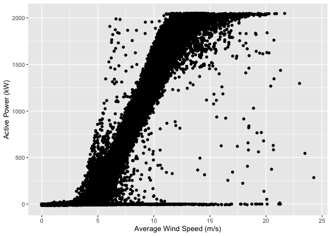

```r
ggplot(haute, aes(x = Wind_speed_avg, y = Active_power_avg))+
  geom_point() +
  labs(x = "Average Wind Speed (m/s)", y = "Active Power (kW)")
```

The same will be roughly true no matter which turbine we are looking at. Below, the data is faceted by individual turbine.

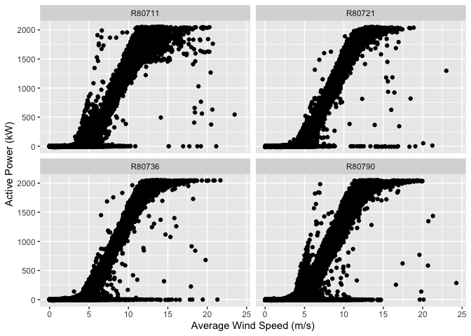

```r
ggplot(haute, aes(x = Wind_speed_avg, y = Active_power_avg))+
  geom_point() +
  labs(x = "Average Wind Speed (m/s)", y = "Active Power (kW)") +
  facet_wrap(~Wind_turbine_name)
```

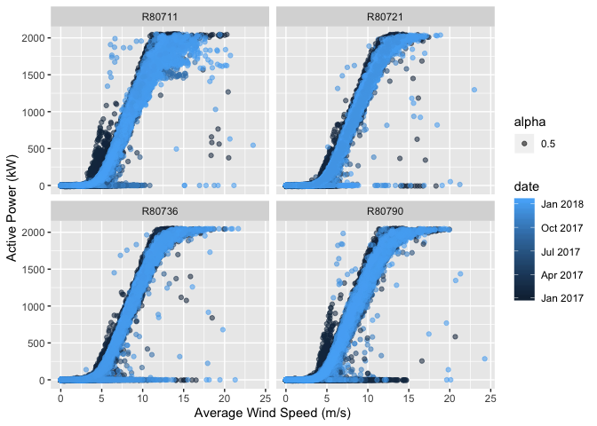

```r
ggplot(haute, aes(x = Wind_speed_avg, y = Active_power_avg))+
  geom_point(aes(color = date, alpha = .5)) +
  labs(x = "Average Wind Speed (m/s)", y = "Active Power (kW)") +
  facet_wrap(~Wind_turbine_name)
```

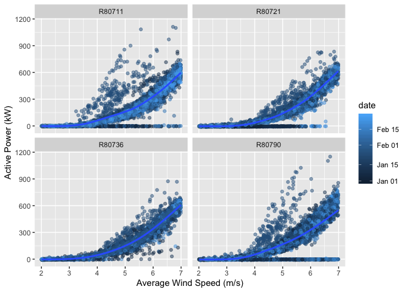

```r
haute %>%
  filter(date < as.Date("2017-2-28")) %>%
  filter(Wind_speed_avg < 7) %>%
  filter(Wind_speed_avg > 2) %>%
  ggplot(., aes(x = Wind_speed_avg, y = Active_power_avg))+
  labs(x = "Average Wind Speed (m/s)", y = "Active Power (kW)") +
  geom_point(aes(color = date), alpha = .5) +
  facet_wrap(~Wind_turbine_name) +
  geom_smooth()
```

Now lets try comparing wind speeds over time, and how the active power is affected. Maybe that will clarify some things. Over a full year period, the plot below shows some densely packed periods of wind increase and decrease, with a generally corresponding increase and decrease of Active Power. The dark spikes seem to indicate low to zero active power at high wind speeds.

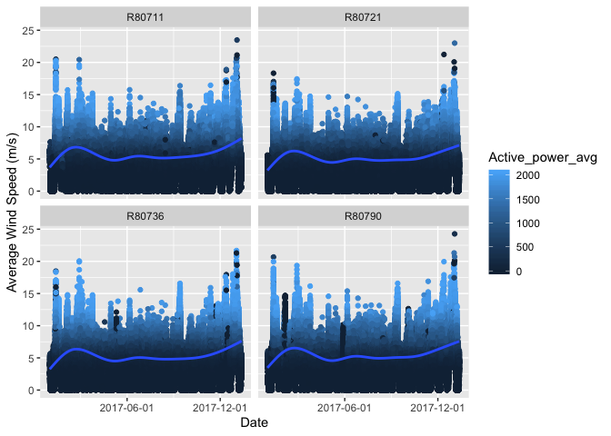

```r
ggplot(haute, aes(x = date, y = Wind_speed_avg)) +
  geom_point(aes(color = Active_power_avg))+
  geom_smooth() +
  labs(x = "Date", y = "Average Wind Speed (m/s)") +
  scale_x_date(date_breaks = "6 month") +
  facet_wrap(~Wind_turbine_name)
```

As an experiment, lets try to isolate the darkest spike in the R80790 time series. Since this is an unexpected lack of Active Power at high wind speeds, we’ll filter out that turbine, and filter a date range that will give us a better spread of data points in our plot, a nine day period in which the spike occurs. We’ll continue mapping Active Power to color, but change the date break to 1 day instead of 6 months so we can see which days exactly we are talking about. The plot, shown below, tells us that the spike from the plot above is really just a two day period, February 3rd and 4th of 2017, when despite the windy conditions, and the three other turbines producing power, this turbine was not producing. We might be able to figure out if it was down for service from looking at service records, or we can read into the data to figure out if something else was created a fault and if there might be a way to predicet that fault, if in fact it can be considered a fault.

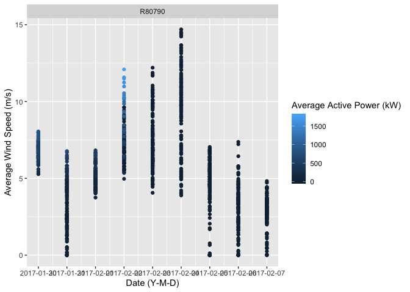

```r
haute %>%
  filter(date < as.Date("2017-02-8")) %>%
  filter(date > as.Date("2017-01-29")) %>%
  filter(Wind_turbine_name == "R80790") %>%
  ggplot(aes(x = date, y = Wind_speed_avg)) +
  geom_point(aes(color = Active_power_avg))+
  geom_smooth() +
  labs(x = "Date (Y-M-D)", y = "Average Wind Speed (m/s)", color = "Average Active Power (kW)") +
  scale_x_date(date_breaks = "1 day") +
  facet_wrap(~Wind_turbine_name)
```

Now I’ll reproduce see the same exact plot but for all four turbines. Looks like the wind speed and active power are pretty similar across turbines that week, except where R80790 goes dark for two days.

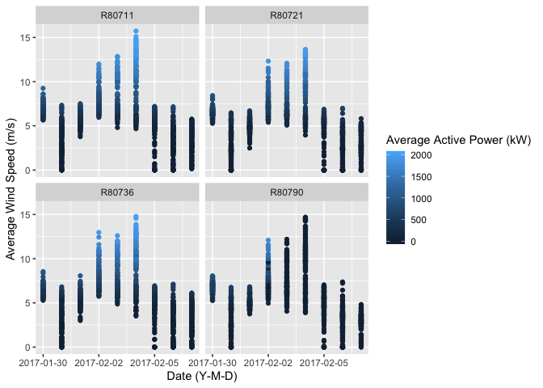

```r
haute %>%
  filter(date < as.Date("2017-02-8")) %>%
  filter(date > as.Date("2017-01-29")) %>%
  ggplot(aes(x = date, y = Wind_speed_avg)) +
  geom_point(aes(color = Active_power_avg))+
  geom_smooth() +
  labs(x = "Date (Y-M-D)", y = "Average Wind Speed (m/s)", color = "Average Active Power (kW)") +
  scale_x_date(date_breaks = "3 day") +
  facet_wrap(~Wind_turbine_name)
```

I want to filter more precisely, and just look at the first of the ‘down’ days, and compare the turbines on some other features during that day. It would be best if I could get the time column into a time format that makes sense.

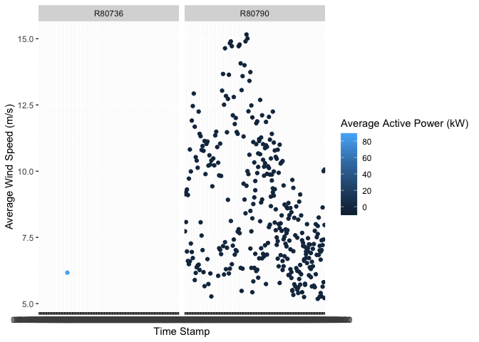

```r
haute %>%
  filter(date < as.Date("2017-02-5")) %>%
  filter(date > as.Date("2017-01-29")) %>%
  filter(Active_power_avg < 100) %>%
  filter(Wind_speed_avg > 5) %>%
  ggplot(aes(x = time, y = Wind_speed1_avg)) +
  labs(x = "Time Stamp", y = "Average Wind Speed (m/s)", color = "Average Active Power (kW)") +
  geom_point(aes(color = Active_power_avg))+
  geom_smooth() +
  facet_wrap(~Wind_turbine_name)
```

Can I see the entire data set with these filters, when the wind speed is above 5 m/s?

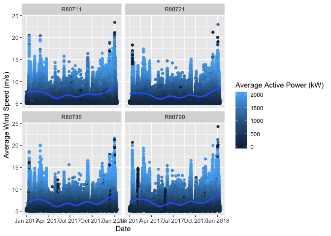

```r
haute %>%
  filter(Wind_speed_avg > 5) %>%
    ggplot(aes(x = date, y = Wind_speed_avg)) +
  geom_point(aes(color = Active_power_avg))+
  geom_smooth() +
  labs(x = "Date", y = "Average Wind Speed (m/s)", color = "Average Active Power (kW)") +
  facet_wrap(~Wind_turbine_name)
```

**Other Variables Explored**

The grid operates at 50Hz, when does grid frequency drop below 50 Hertz, and does this tell us anything?:

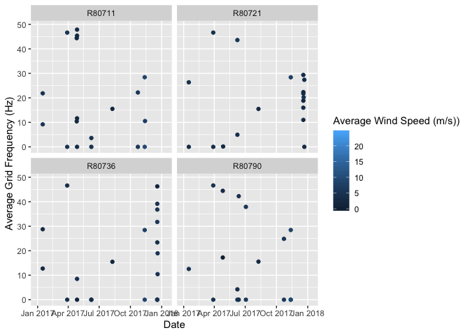

```r
ggplot(haute, aes(x = date, y = Grid_frequency_avg)) +
  geom_point(aes(color = Wind_speed_avg)) +
  facet_wrap(~Wind_turbine_name) +
  labs(x = "Date", y = "Average Grid Frequency (Hz)", color = "Average Wind Speed (m/s))") +
  scale_y_continuous(limits = c(0,49))
```

The relationship between active and reactive power:

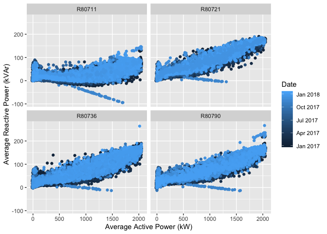

```r
ggplot(haute, aes(x = Active_power_avg, y = Reactive_power_avg, color = date)) +
  geom_point() +
  labs(x = "Average Active Power (kW)", y = "Average Reactive Power (kVAr)", color = "Date") +
  facet_wrap(~Wind_turbine_name)
```

In all 4 wind turbines there is a cluster offshoot where the relationship between active power and reactive power is inverted. This is interesting but may be beyond the scope of this project, and beyond my domain knowledge. I will stick with the relationship between wind speed and active power. In particular I am interested in those data points where Wind Speed is high enough that we would expect a certain level of Active Power, but in fact the Active Power is below a certain threshold. I will define this more specifically in the feature engineering phase of the project.

**Feature Engineering**

In the exploration phase of the project, there was a lot that jumped out as interesting. But I decided to focus on instances of turbines not functioning as intended. This will require first some feature engineering. I will create a new feature “down” that displays a 1 if the wind speed is above 5 m/s but average active power is below 50 kW. In other words, a feature that tells me when a turbine “should” be producing power, but is not. This is a simplification, but it sets us up with a binary feature that could be re-engineered in many different ways, and one that allows for the application of machine learning approaches like logistic regression and k-fold Cross Validation.

```r
down <- ifelse(haute$Wind_speed_avg > 5 & haute$Active_power_avg < 50, 1, 0)
summary(down)
```

```
##    Min. 1st Qu.  Median    Mean 3rd Qu.    Max.    NA's
##  0.0000  0.0000  0.0000  0.0115  0.0000  1.0000    1658
```

```r
haute$down <- as.factor(down)
class(haute$down)
```

```
## [1] "factor"
```

Here I want to create a subset that includes all of my features, including min and max values, and the new feature down but remove turbine ID, date, time. Since I wont be doing any time series analysis. I will also remove all wind and power related features, since they are baked into the feature “down”.

```r
down <- haute$down
haute_clean <- select(haute, -c(1,2,3))
haute_clean <- haute_clean %>%
                  select(-contains("Wind")) %>%
                  select(-contains("Power"))
```

I will view the number of missing values in each column.

```r
missing.values <- haute_clean %>%
  gather(key = "key", value = "val") %>%
  mutate(is.missing = is.na(val)) %>%
  group_by(key, is.missing) %>%
  summarise(num.missing = n()) %>%
  filter(is.missing==T) %>%
  select(-is.missing) %>%
  arrange(desc(num.missing))
missing.values
```

```
## # A tibble: 97 x 2
## # Groups:   key [97]
##    key                         num.missing
##    <chr>                             <int>
##  1 Nacelle_angle_corrected_max      217588
##  2 Nacelle_angle_corrected_min      217588
##  3 Nacelle_angle_corrected_std      217588
##  4 Nacelle_angle_corrected_avg      183657
##  5 Vane_position_avg                140456
##  6 Vane_position_max                140456
##  7 Vane_position_min                140456
##  8 Vane_position_std                140456
##  9 Vane_position1_avg                79081
## 10 Vane_position1_max                79081
## # … with 87 more rows
```

```r
haute_complete <- haute_clean %>%
                drop_na(down)
```

I will remove the columns from the dataset with the most NAs (where over a third of rows are missing values). This could be a place for further experimentation later on, but for now, I will remove them.

```r
haute_complete <- haute_clean
haute_complete <- haute_complete %>%
                  select(-contains("Vane_position")) %>%
                  select(-contains("Nacelle_angle_corrected"))
```

Now haute_complete is the working dataset. I will check the balance. This will be important as the model used on the data will be logistic regression. This will also be considered the baseline prediction for negative cases.

```r
table(haute_complete$down)
```

```
##
##      0      1
## 213451   2479
```

```r
down_table <- table(haute_complete$down)
down_table
```

```
##
##      0      1
## 213451   2479
```

```r
down_table[1]/(down_table[1] + down_table[2])
```

```
##         0
## 0.9885194
```

A plot of the full dataset with “down” mapped to color will highlight the cases I am interested in predicting.

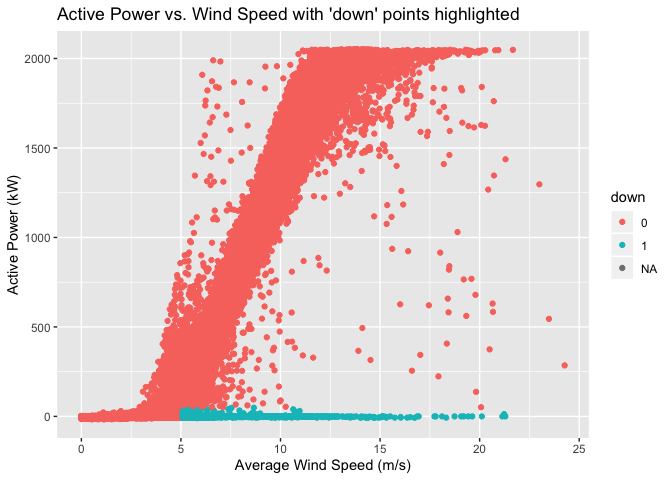

```r
ggplot(haute, aes(x = Wind_speed_avg, y = Active_power_avg))+
  geom_point(aes(color = down)) +
  labs(x = "Average Wind Speed (m/s)", y = "Active Power (kW)") +
  ggtitle("Active Power vs. Wind Speed with 'down' points highlighted")
```

**Machine Learning**

```r
library(caret)
library(DMwR)
set.seed(2555)
smote_haute <- SMOTE(down ~ ., data = as.data.frame(haute_complete))
smoted_haute <- table(smote_haute$down)
smoted_haute
```

```
##
##    0    1
## 9846 7437
```

```r
smoted_haute[2]/smoted_haute[1]
```

```
##         1
## 0.7553321
```

```r
smote_haute <- tbl_df(smote_haute)
```

Now I want to check out the missing values after using SMOTE:

```r
missing.values <- smote_haute %>%
  gather(key = "key", value = "val") %>%
  mutate(is.missing = is.na(val)) %>%
  group_by(key, is.missing) %>%
  summarise(num.missing = n()) %>%
  filter(is.missing==T) %>%
  select(-is.missing) %>%
  arrange(desc(num.missing))
missing.values
```

```
## # A tibble: 81 x 2
## # Groups:   key [81]
##    key                 num.missing
##    <chr>                     <int>
##  1 Torque_avg                 1500
##  2 Torque_max                 1500
##  3 Torque_min                 1500
##  4 Torque_std                 1500
##  5 Rotor_speed_avg            1115
##  6 Rotor_speed_max            1115
##  7 Rotor_speed_min            1115
##  8 Rotor_speed_std            1115
##  9 Generator_speed_avg         618
## 10 Generator_speed_max         618
## # … with 71 more rows
```

```r
library(caTools)
```

```r
smote_haute_omitted <- na.omit(smote_haute)
split <- sample.split(smote_haute_omitted$down, SplitRatio = .65)
train <- subset(smote_haute_omitted, split == TRUE)
test <- subset(smote_haute_omitted, split == FALSE)
table(train$down)
```

```
##
##    0    1
## 6304 3914
```

```r
table(test$down)
```

```
##
##    0    1
## 3394 2107
```

I will create a logistic regression model to predict down, based on the training data.

```r
trainlogistic <- glm(down ~ ., data = train, family = binomial)
summary(trainlogistic)
```

```
##
## Call:
## glm(formula = down ~ ., family = binomial, data = train)
##
## Deviance Residuals:
##     Min       1Q   Median       3Q      Max
## -4.1401  -0.0001   0.0000   0.1781   4.4611
##
## Coefficients:
##                                       Estimate Std. Error z value Pr(>|z|)
## (Intercept)                         -1.400e+01  2.011e+00  -6.961 3.37e-12
## Pitch_angle_avg                      1.019e-01  2.964e-02   3.438 0.000585
## Pitch_angle_min                     -4.348e-02  2.831e-02  -1.536 0.124564
## Pitch_angle_max                      9.837e-02  3.429e-02   2.868 0.004126
## Pitch_angle_std                     -1.498e-01  7.686e-02  -1.949 0.051321
## Hub_temperature_avg                 -6.434e-01  3.435e-01  -1.873 0.061082
## Hub_temperature_min                  1.460e-01  3.127e-01   0.467 0.640706
## Hub_temperature_max                  2.856e-01  3.301e-01   0.865 0.386794
## Hub_temperature_std                 -2.900e+00  8.092e-01  -3.584 0.000338
## Generator_converter_speed_avg       -1.160e-01  3.649e-02  -3.178 0.001483
## Generator_converter_speed_min        1.037e-01  4.332e-02   2.394 0.016662
## Generator_converter_speed_max       -4.099e-02  2.681e-02  -1.529 0.126318
## Generator_converter_speed_std       -7.327e-03  7.933e-02  -0.092 0.926406
## Converter_torque_avg                -1.197e-02  3.709e-03  -3.226 0.001255
## Converter_torque_min                -5.006e-03  3.499e-03  -1.431 0.152453
## Converter_torque_max                -1.265e-02  3.210e-03  -3.941 8.13e-05
## Converter_torque_std                 1.589e-02  4.787e-03   3.319 0.000903
## Generator_speed_avg                  1.614e-01  5.092e-02   3.169 0.001529
## Generator_speed_min                 -3.523e-02  4.748e-02  -0.742 0.458100
## Generator_speed_max                  5.189e-02  3.054e-02   1.699 0.089310
## Generator_speed_std                  5.114e-02  1.059e-01   0.483 0.629196
## Generator_bearing_1_temperature_avg  1.033e-01  9.628e-01   0.107 0.914549
## Generator_bearing_1_temperature_min  5.458e-01  5.411e-01   1.009 0.313188
## Generator_bearing_1_temperature_max -4.687e-01  1.182e+00  -0.397 0.691613
## Generator_bearing_1_temperature_std  6.417e-01  2.653e+00   0.242 0.808876
## Generator_bearing_2_temperature_avg -8.108e-01  1.270e+00  -0.638 0.523219
## Generator_bearing_2_temperature_min -2.351e-01  1.228e+00  -0.191 0.848196
## Generator_bearing_2_temperature_max  7.200e-01  9.941e-01   0.724 0.468929
## Generator_bearing_2_temperature_std -1.051e+00  2.837e+00  -0.370 0.711035
## Generator_stator_temperature_avg     1.844e+00  7.521e-01   2.453 0.014186
```

[output cut: 128 more lines]

```
## Rotor_bearing_temperature_std
## Torque_avg
## Torque_min                          **
## Torque_max                          ***
## Torque_std                          **
## ---
## Signif. codes:  0 '***' 0.001 '**' 0.01 '*' 0.05 '.' 0.1 ' ' 1
##
## (Dispersion parameter for binomial family taken to be 1)
##
##     Null deviance: 13601  on 10217  degrees of freedom
## Residual deviance:  1628  on 10137  degrees of freedom
## AIC: 1790
##
## Number of Fisher Scoring iterations: 15
```

**Predictions**

Now I will predict in the test set which turbines are down, using the logistic regression model I have just made

```r
predictTest <- predict(trainlogistic, type = "response", newdata = test)
table(test$down)
```

```
##
##    0    1
## 3394 2107
```

```r
table(test$down, predictTest > .5)
```

```
##
##     FALSE TRUE
##   0  3270  124
##   1    34 2073
```

I will visualize the results in a confusion matrix:

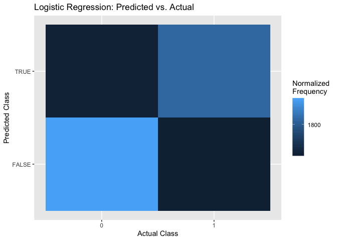

```r
input.matrix <- data.matrix(table(test$down, predictTest > .5))

colnames(input.matrix) = c(FALSE, TRUE)
rownames(input.matrix) = c(0, 1)

glmconfusion <- as.data.frame(as.table(input.matrix))
b <- c(0, 1800, 3500)
plot <- ggplot(glmconfusion)
plot +
  geom_tile(aes(x=Var1, y=Var2, fill=Freq)) +
        labs(fill = "Normalized\nFrequency") +
        scale_x_discrete(name="Actual Class") +
        scale_y_discrete(name="Predicted Class") +
        scale_fill_gradient(breaks=b, labels = format(b)) +
        ggtitle("Logistic Regression: Predicted vs. Actual")
```

I will measure the performance of this model overall by measuring the area under the ROC curve and plotting it.

```r
library(ROCR)
ROCRpred <- prediction(predictTest, test$down)
as.numeric(performance(ROCRpred, "auc")@y.values)
```

```
## [1] 0.993741
```

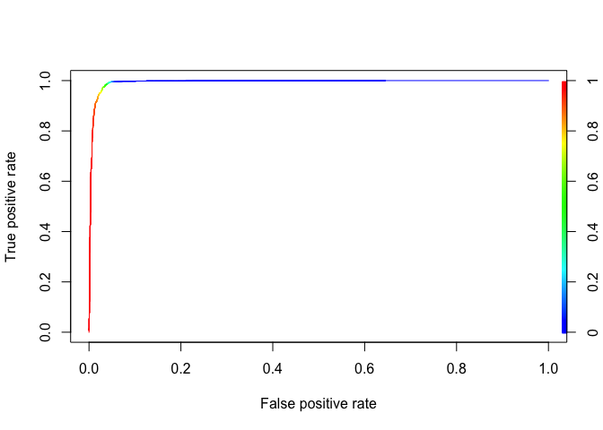

```r
perf <- performance(ROCRpred,"tpr","fpr")
plot(perf,colorize=TRUE)
```

Logistic regression produces some result, though it is problematic (I will talk about this in the report). I will try cross validation.

```r
ctrl <- trainControl(method = "repeatedcv", number = 10, savePredictions = TRUE)

mod_fit <- train(down ~ .,  data = train, method="glm", family="binomial",
                 trControl = ctrl, tuneLength = 5)

predCV <- predict(mod_fit, newdata = test)

summary(predCV)
```

```
##    0    1
## 3304 2197
```

And visualize the confusion matrix for this as well.

```r
table(predCV, test$down)
```

```
##
## predCV    0    1
##      0 3270   34
##      1  124 2073
```

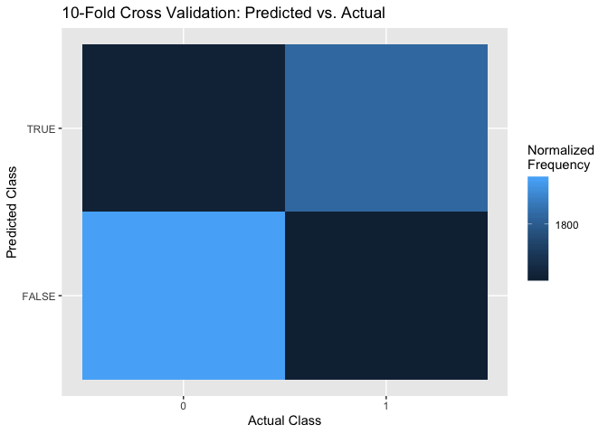

```r
confusion2 <- confusionMatrix(data = predCV, test$down)

input.matrix2 <- data.matrix(table(test$down, predictTest > .5))


colnames(input.matrix2) = c(FALSE, TRUE)
rownames(input.matrix2) = c(0, 1)

confusion2 <- as.data.frame(as.table(input.matrix))
b <- c(0, 1800, 3500)
plot2 <- ggplot(confusion2)
plot2 +
  geom_tile(aes(x=Var1, y=Var2, fill=Freq)) +
        labs(fill = "Normalized\nFrequency") +
        scale_x_discrete(name="Actual Class") +
        scale_y_discrete(name="Predicted Class") +
        scale_fill_gradient(breaks=b, labels = format(b)) +
        ggtitle("10-Fold Cross Validation: Predicted vs. Actual")
```

Accuracy for the GLM prediction by area under the curve.

```r
as.numeric(performance(ROCRpred, "auc")@y.values)
```

```
## [1] 0.993741
```

```r
table(test$down, predictTest > .5)
```

```
##
##     FALSE TRUE
##   0  3270  124
##   1    34 2073
```

Accuracy for the cross validation.

```r
confusionMatrix(predCV, test$down)
```

```
## Confusion Matrix and Statistics
##
##           Reference
## Prediction    0    1
##          0 3270   34
##          1  124 2073
##
##                Accuracy : 0.9713
##                  95% CI : (0.9665, 0.9755)
##     No Information Rate : 0.617
##     P-Value [Acc > NIR] : < 2.2e-16
##
##                   Kappa : 0.9397
##
##  Mcnemar's Test P-Value : 1.437e-12
##
##             Sensitivity : 0.9635
##             Specificity : 0.9839
##          Pos Pred Value : 0.9897
##          Neg Pred Value : 0.9436
##              Prevalence : 0.6170
##          Detection Rate : 0.5944
##    Detection Prevalence : 0.6006
##       Balanced Accuracy : 0.9737
##
##        'Positive' Class : 0
##
```